# Deep Learning Systems (ENGR-E 533) Homework 4 , Fall 2021

**Name: Anitha Ganapathy**  
**Email: aganapa@iu.edu**

# Siamese Neural Network (SNN)

## Build a speaker verification system.

**Organize Import statements**

```python
#import some basic libraries
import tensorflow as tf
import keras
from keras.datasets import mnist
from keras.models import Sequential

from tensorflow.keras.callbacks import Callback
from tensorflow.keras.models import Sequential
from keras.layers import Activation, Flatten, Dense, Dropout, Input
from tensorflow.keras.losses import SparseCategoricalCrossentropy
from keras.layers.convolutional import Conv2D, MaxPooling2D
from keras.layers import Activation, Flatten, Dense, Dropout, LSTM
from keras.layers import BatchNormalization
from keras import backend as K
from tensorflow.keras.layers import Dot
from tensorflow.keras.activations import sigmoid


import numpy as np
import math
import random
import matplotlib.pyplot as plt
from tensorflow.keras import layers
from keras.backend import count_params
import tensorflow.keras.backend as K
from tensorflow.keras import Model
from tensorflow.keras.utils import Sequence
from tensorflow.keras.activations import sigmoid
from tensorflow.keras.metrics import BinaryAccuracy
%matplotlib inline

import pandas as pd
import glob
import librosa
import pickle
from itertools import combinations

from google.colab import drive

drive.mount('/content/drive' ,force_remount =  True)
```

## Problem 4: Speaker Verification

```python
dirpath = '/content/drive/MyDrive/data/'
# dirpath = '/content/'
```

```python
!ls $dirpath
```

```
Hw2  hw4_tes.pkl  hw4_trs.pkl  models
```

## Data download.

**Load train data**

```python
# Each speaker has 10 utterances, and there are 50 such speakers
# (that's why there are 500 rows)

hw4_train_pkl = open(dirpath+"hw4_trs.pkl", "rb")
hw4_train_data = pickle.load(hw4_train_pkl)

print('Shape of training: ', hw4_train_data.shape)
```

```
Shape of training:  (500, 16180)
```

**Load test data**

```python
# test set has 20 speakers, each of which is with 10 utterances.

hw4_test_pkl = open(dirpath+"hw4_tes.pkl", "rb")
hw4_test_data = pickle.load(hw4_test_pkl)

print('Shape of training: ', hw4_test_data.shape)
```

```
Shape of training:  (200, 22631)
```

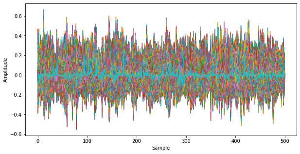

```
CPU times: user 27.1 s, sys: 942 ms, total: 28.1 s
Wall time: 27.2 s
```

```python
%%time
# Plot the signal

# plt.subplot(211)
fig = plt.figure(figsize=(10,5))
plt.plot(hw4_train_data)

plt.xlabel('Sample')

plt.ylabel('Amplitude')
plt.show()
```

Function to STFT train and test data

```python
def stft(data):
  S_stft = librosa.stft(data, n_fft=1024, hop_length=512)
  return S_stft
```

Pre-process train and test data by creating positive sample of combining spectrograms of same speakers and negative samples of combining spectrograms of different speakers.I have done zero padding for train spectograms to have 45x513 dimensions as the train spectogram is shorter than the test

## Create Positive Pairs

Generates all combinations of pairs and randomly selects L pairs from it.

```python
def create_pos_pairs(speaker, L=45):
    batch = []
    all_pairs = list(combinations(range(10), 2))
    l_pairs = random.sample(all_pairs, L)
    for a,b in l_pairs:
        stft_1 = np.abs(librosa.stft(speaker[a], n_fft=1024, hop_length=512)).T
        stft_2 = np.abs(librosa.stft(speaker[b], n_fft=1024, hop_length=512)).T
        batch.append([stft_1, stft_2])
    return batch
```

## Create Negative Pairs

The Main Speaker's utternaces lie between start and end. The other 49 speakers' utterances like before start and after end. Randomly sample L utterances from the main speaker's utterances with replacement as L is greater than the number of utterances by the main speaker, i.e., L>10. Whereas, we randomly sample L utterances from the other 49 speakers' utterances without replacement as L is less than their total utterances L<490. Using the samples from the above 2 steps we create Negative Pairs

```python
def create_neg_pairs(pos_sp_num, data, L=45):
    batch = []

    start = pos_sp_num*10
    end = start + 10
    pos_spk = data[start: end]
    neg_spk = data[:start] + data[end:]
    neg_sample = random.sample(neg_spk, L)

    for l in range(L):
        pos = random.choice(pos_spk)

        stft_pos = np.abs(librosa.stft(pos, n_fft=1024, hop_length=512)).T
        stft_neg = np.abs(librosa.stft(neg_sample[l], n_fft=1024, hop_length=512)).T
        batch.append([stft_pos, stft_neg])

    return batch
```

## Create Training Pairs

Creates 2250 pairs of negative and positive examples each, i.e, 4500 total pairs. Final Dimensions - Pairs (4500) x Number of Inputs (2) x Shape of Spectrogram (45x513) x number of channels (1)

```python
mini_batches = []
train_data = list(hw4_train_data)
for i in range(50):
    pos_batch = create_pos_pairs(train_data[i:i+10])
    neg_batch = create_neg_pairs(i, train_data)
    mini_batches += pos_batch + neg_batch
#     mini_batches.append(mini_batch)
```

```python
mini_np = np.stack(mini_batches)
```

```python
mini_np.shape
```

```
(4500, 2, 32, 513)
```

```python
mini_np = np.pad(mini_np, ((0,0), (0,0), (0, 13), (0,0)), mode = 'constant', constant_values = 0)
print(mini_np.shape)
```

```
(4500, 2, 45, 513)
```

## Create True Predictions based on the negative/positive pairs

```python
Y = []
for i in range(50):
    y = np.zeros(90, dtype = int)
    y[:45] += 1
    Y.append(y)
Y = np.hstack(Y)
```

## Create Testing Pairs

Creates 900 pairs of negative and positive examples each, i.e, 1800 total pairs. Final Dimensions - Pairs (1800) x Number of Inputs (2) x Shape of Spectrogram (45x513) x number of channels (1)

```python
mini_batches_test = []
test_data = list(hw4_test_data)
for i in range(20):
    pos_batch = create_pos_pairs(test_data[i:i+10])
    neg_batch = create_neg_pairs(i, test_data)
    mini_batches_test += pos_batch + neg_batch
```

```python
mini_np_test = np.stack(mini_batches_test)

mini_np_test.shape
```

```
(1800, 2, 45, 513)
```

```python
# The Glorot normal initializer, also called Xavier normal initializer.

def siamese_network():
  left_input = Input(shape=(None, 513))
  right_input = Input(shape=(None, 513))

  xavier_init = tf.keras.initializers.glorot_normal

  # base_model = Sequential([
  #     Conv2D(filters= 20, kernel_size=(4, 2), activation='relu', strides =1,
  #             kernel_initializer= xavier_init, # padding = 'same',
  #             input_shape= (45, 513, 1)),
  #     MaxPooling2D(pool_size=(2, 2), strides=2, padding='same'),
  #     Conv2D(filters=20, kernel_size=(4, 2), activation='relu', strides=1,
  #           # padding = 'same',
  #            kernel_initializer= xavier_init),
  #     MaxPooling2D(pool_size=(2, 2), strides=2),
  #     Flatten(),
  #     Dense(units=200, activation='relu' , kernel_initializer=xavier_init),
  #     Dropout(0.7),
  #     Dense(units=513, activation='tanh' , kernel_initializer=xavier_init)
  # ])


  base_model = Sequential([
      LSTM(128, return_sequences=True),
      BatchNormalization(),
      Dropout(0.8),
      LSTM(64, return_sequences=False),
      BatchNormalization(),
      Dropout(0.8),
      Dense(64, activation='tanh', kernel_regularizer='l2'),
      Dropout(0.2)
  ])

  left_output = base_model(left_input)
  right_output = base_model(right_input)

  print(K.shape(left_output))
  print(K.shape(right_output))

  # prediction = tf.reduce_sum(tf.multiply(left_output, right_output), axis = 1)
  # prediction = tf.reshape(prediction, [-1, 1])

  inner_product = Dot(axes=1)([left_output, right_output])
  prediction = sigmoid(inner_product)

  siamese_model = Model(inputs = [left_input, right_input], outputs = prediction)

  return siamese_model
```

```python
snn_model = siamese_network()
snn_model.summary()
```

```
KerasTensor(type_spec=TensorSpec(shape=(2,), dtype=tf.int32, name=None), inferred_value=[None, 64], name='tf.compat.v1.shape/Shape:0', description="created by layer 'tf.compat.v1.shape'")
KerasTensor(type_spec=TensorSpec(shape=(2,), dtype=tf.int32, name=None), inferred_value=[None, 64], name='tf.compat.v1.shape_1/Shape:0', description="created by layer 'tf.compat.v1.shape_1'")
Model: "model"
__________________________________________________________________________________________________
 Layer (type)                   Output Shape         Param #     Connected to
==================================================================================================
 input_1 (InputLayer)           [(None, None, 513)]  0           []

 input_2 (InputLayer)           [(None, None, 513)]  0           []

 sequential (Sequential)        (None, 64)           383040      ['input_1[0][0]',
                                                                  'input_2[0][0]']

 dot (Dot)                      (None, 1)            0           ['sequential[0][0]',
                                                                  'sequential[1][0]']

 tf.math.sigmoid (TFOpLambda)   (None, 1)            0           ['dot[0][0]']

==================================================================================================
Total params: 383,040
Trainable params: 382,656
Non-trainable params: 384
__________________________________________________________________________________________________
```

```python
def loss(y_true, y_pred):
    return tf.reduce_sum(tf.compat.v1.losses.sigmoid_cross_entropy(y_true, y_pred))
```

```python
snn_model.compile(loss=tf.keras.losses.BinaryCrossentropy(from_logits=True),
                  optimizer = tf.keras.optimizers.Adam(learning_rate=1e-4),
                  metrics=['accuracy'])
```

```python
Y_test = []
for i in range(20):
    y = np.zeros(90, dtype = int)
    y[:45] += 1
    Y_test.append(y)
Y_test = np.hstack(Y_test)
```

```python
mini_np.shape, Y.shape, mini_np_test.shape, Y_test.shape
```

```
((4500, 2, 45, 513), (4500,), (1800, 2, 45, 513), (1800,))
```

```python
mini_np = tf.convert_to_tensor(mini_np)
Y = tf.convert_to_tensor(Y)
mini_np_test = tf.convert_to_tensor(mini_np_test)
Y_test = tf.convert_to_tensor(Y_test)
```

```python
mini_np.shape, Y.shape, mini_np_test.shape, Y_test.shape
```

```
(TensorShape([4500, 2, 45, 513]),
 TensorShape([4500]),
 TensorShape([1800, 2, 45, 513]),
 TensorShape([1800]))
```

```python
%%time

snn_model_history =  snn_model.fit([mini_np[:, 0], mini_np[:, 1]], Y,
                                   batch_size=64,
                                   epochs=100,
                                   validation_data=([mini_np_test[:, 0], mini_np_test[:, 1]] ,Y_test),
                                   verbose=2
                                   )
```

```
71/71 - 9s - loss: 1.3670 - accuracy: 0.5073 - val_loss: 1.4233 - val_accuracy: 0.5022 - 9s/epoch - 125ms/step
71/71 - 2s - loss: 1.3476 - accuracy: 0.5051 - val_loss: 1.4015 - val_accuracy: 0.5056 - 2s/epoch - 22ms/step
71/71 - 2s - loss: 1.3361 - accuracy: 0.4907 - val_loss: 1.3769 - val_accuracy: 0.5189 - 2s/epoch - 22ms/step
71/71 - 2s - loss: 1.3220 - accuracy: 0.4880 - val_loss: 1.3584 - val_accuracy: 0.5211 - 2s/epoch - 22ms/step
71/71 - 2s - loss: 1.2992 - accuracy: 0.4993 - val_loss: 1.3384 - val_accuracy: 0.5261 - 2s/epoch - 22ms/step
71/71 - 2s - loss: 1.2765 - accuracy: 0.5042 - val_loss: 1.3195 - val_accuracy: 0.5272 - 2s/epoch - 22ms/step
71/71 - 2s - loss: 1.2632 - accuracy: 0.5009 - val_loss: 1.3068 - val_accuracy: 0.5244 - 2s/epoch - 22ms/step
71/71 - 2s - loss: 1.2467 - accuracy: 0.5011 - val_loss: 1.2931 - val_accuracy: 0.5194 - 2s/epoch - 22ms/step
71/71 - 2s - loss: 1.2321 - accuracy: 0.5020 - val_loss: 1.2779 - val_accuracy: 0.5217 - 2s/epoch - 22ms/step
71/71 - 2s - loss: 1.2187 - accuracy: 0.4993 - val_loss: 1.2602 - val_accuracy: 0.5272 - 2s/epoch - 22ms/step
71/71 - 2s - loss: 1.2090 - accuracy: 0.4944 - val_loss: 1.2455 - val_accuracy: 0.5261 - 2s/epoch - 22ms/step
71/71 - 2s - loss: 1.1883 - accuracy: 0.5020 - val_loss: 1.2347 - val_accuracy: 0.5239 - 2s/epoch - 22ms/step
71/71 - 2s - loss: 1.1741 - accuracy: 0.5087 - val_loss: 1.2205 - val_accuracy: 0.5244 - 2s/epoch - 22ms/step
71/71 - 2s - loss: 1.1621 - accuracy: 0.5027 - val_loss: 1.2081 - val_accuracy: 0.5239 - 2s/epoch - 22ms/step
71/71 - 2s - loss: 1.1544 - accuracy: 0.4922 - val_loss: 1.1961 - val_accuracy: 0.5244 - 2s/epoch - 22ms/step
71/71 - 2s - loss: 1.1392 - accuracy: 0.4989 - val_loss: 1.1851 - val_accuracy: 0.5233 - 2s/epoch - 22ms/step
71/71 - 2s - loss: 1.1348 - accuracy: 0.4858 - val_loss: 1.1734 - val_accuracy: 0.5239 - 2s/epoch - 22ms/step
71/71 - 2s - loss: 1.1142 - accuracy: 0.5022 - val_loss: 1.1624 - val_accuracy: 0.5233 - 2s/epoch - 22ms/step
71/71 - 2s - loss: 1.1048 - accuracy: 0.5038 - val_loss: 1.1523 - val_accuracy: 0.5228 - 2s/epoch - 22ms/step
71/71 - 2s - loss: 1.0916 - accuracy: 0.5067 - val_loss: 1.1429 - val_accuracy: 0.5206 - 2s/epoch - 22ms/step
71/71 - 2s - loss: 1.0830 - accuracy: 0.5047 - val_loss: 1.1322 - val_accuracy: 0.5217 - 2s/epoch - 22ms/step
71/71 - 2s - loss: 1.0736 - accuracy: 0.5022 - val_loss: 1.1209 - val_accuracy: 0.5256 - 2s/epoch - 22ms/step
71/71 - 2s - loss: 1.0693 - accuracy: 0.4880 - val_loss: 1.1119 - val_accuracy: 0.5250 - 2s/epoch - 22ms/step
71/71 - 2s - loss: 1.0536 - accuracy: 0.5087 - val_loss: 1.1026 - val_accuracy: 0.5244 - 2s/epoch - 22ms/step
71/71 - 2s - loss: 1.0431 - accuracy: 0.5100 - val_loss: 1.0936 - val_accuracy: 0.5239 - 2s/epoch - 22ms/step
71/71 - 2s - loss: 1.0393 - accuracy: 0.4956 - val_loss: 1.0869 - val_accuracy: 0.5228 - 2s/epoch - 22ms/step
71/71 - 2s - loss: 1.0269 - accuracy: 0.5100 - val_loss: 1.0770 - val_accuracy: 0.5256 - 2s/epoch - 22ms/step
71/71 - 2s - loss: 1.0189 - accuracy: 0.5067 - val_loss: 1.0696 - val_accuracy: 0.5256 - 2s/epoch - 22ms/step
71/71 - 2s - loss: 1.0171 - accuracy: 0.4889 - val_loss: 1.0627 - val_accuracy: 0.5228 - 2s/epoch - 22ms/step
71/71 - 2s - loss: 1.0083 - accuracy: 0.4911 - val_loss: 1.0552 - val_accuracy: 0.5233 - 2s/epoch - 22ms/step
71/71 - 2s - loss: 0.9998 - accuracy: 0.4998 - val_loss: 1.0478 - val_accuracy: 0.5233 - 2s/epoch - 22ms/step
71/71 - 2s - loss: 0.9938 - accuracy: 0.4944 - val_loss: 1.0419 - val_accuracy: 0.5211 - 2s/epoch - 22ms/step
71/71 - 2s - loss: 0.9800 - accuracy: 0.5096 - val_loss: 1.0358 - val_accuracy: 0.5194 - 2s/epoch - 22ms/step
71/71 - 2s - loss: 0.9770 - accuracy: 0.4996 - val_loss: 1.0283 - val_accuracy: 0.5222 - 2s/epoch - 22ms/step
71/71 - 2s - loss: 0.9751 - accuracy: 0.4933 - val_loss: 1.0227 - val_accuracy: 0.5194 - 2s/epoch - 22ms/step
71/71 - 2s - loss: 0.9626 - accuracy: 0.5087 - val_loss: 1.0166 - val_accuracy: 0.5189 - 2s/epoch - 22ms/step
71/71 - 2s - loss: 0.9562 - accuracy: 0.5020 - val_loss: 1.0095 - val_accuracy: 0.5222 - 2s/epoch - 22ms/step
71/71 - 2s - loss: 0.9527 - accuracy: 0.5033 - val_loss: 1.0037 - val_accuracy: 0.5233 - 2s/epoch - 22ms/step
71/71 - 2s - loss: 0.9439 - accuracy: 0.5031 - val_loss: 0.9985 - val_accuracy: 0.5211 - 2s/epoch - 22ms/step
71/71 - 2s - loss: 0.9365 - accuracy: 0.5127 - val_loss: 0.9932 - val_accuracy: 0.5211 - 2s/epoch - 22ms/step
```

[output cut: 47 more lines]

```
71/71 - 2s - loss: 0.7938 - accuracy: 0.5080 - val_loss: 0.8577 - val_accuracy: 0.5189 - 2s/epoch - 22ms/step
71/71 - 2s - loss: 0.7886 - accuracy: 0.5176 - val_loss: 0.8561 - val_accuracy: 0.5206 - 2s/epoch - 22ms/step
71/71 - 2s - loss: 0.7854 - accuracy: 0.5249 - val_loss: 0.8550 - val_accuracy: 0.5189 - 2s/epoch - 22ms/step
71/71 - 2s - loss: 0.7841 - accuracy: 0.5253 - val_loss: 0.8535 - val_accuracy: 0.5194 - 2s/epoch - 22ms/step
71/71 - 2s - loss: 0.7805 - accuracy: 0.5293 - val_loss: 0.8516 - val_accuracy: 0.5200 - 2s/epoch - 22ms/step
71/71 - 2s - loss: 0.7824 - accuracy: 0.5287 - val_loss: 0.8496 - val_accuracy: 0.5189 - 2s/epoch - 22ms/step
71/71 - 2s - loss: 0.7731 - accuracy: 0.5404 - val_loss: 0.8483 - val_accuracy: 0.5183 - 2s/epoch - 22ms/step
71/71 - 2s - loss: 0.7731 - accuracy: 0.5436 - val_loss: 0.8437 - val_accuracy: 0.5211 - 2s/epoch - 22ms/step
71/71 - 2s - loss: 0.7668 - accuracy: 0.5524 - val_loss: 0.8392 - val_accuracy: 0.5283 - 2s/epoch - 22ms/step
71/71 - 2s - loss: 0.7616 - accuracy: 0.5696 - val_loss: 0.8296 - val_accuracy: 0.5400 - 2s/epoch - 22ms/step
71/71 - 2s - loss: 0.7551 - accuracy: 0.5851 - val_loss: 0.8281 - val_accuracy: 0.5389 - 2s/epoch - 22ms/step
71/71 - 2s - loss: 0.7566 - accuracy: 0.5820 - val_loss: 0.8250 - val_accuracy: 0.5333 - 2s/epoch - 22ms/step
71/71 - 2s - loss: 0.7504 - accuracy: 0.5951 - val_loss: 0.8160 - val_accuracy: 0.5483 - 2s/epoch - 21ms/step
CPU times: user 4min 13s, sys: 43.2 s, total: 4min 56s
Wall time: 2min 43s
```

```python
test_accu = snn_model.evaluate([mini_np_test[:, 0], mini_np_test[:, 1]] ,Y[:1800])
```

```python
print(f'Test Accuracy: {test_accu[1]*100} % ', )
```

```
Test Accuracy: 54.83333468437195 %
```

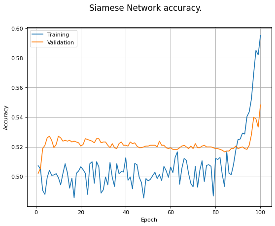

```python
plt.figure(figsize=(8, 6), dpi=80)
plt.plot(range(1,len(snn_model_history.history['accuracy'])+1),
         snn_model_history.history['accuracy'])
plt.plot(range(1,len(snn_model_history.history['val_accuracy'])+1),
         snn_model_history.history['val_accuracy'])
plt.suptitle('Siamese Network accuracy.', fontsize = 15)
plt.grid()
plt.ylabel('Accuracy')
plt.xlabel('Epoch')
plt.legend(['Training', 'Validation'], loc='best')
plt.show()
```

```python
%%time

snn_model_history =  snn_model.fit([mini_np[:, 0], mini_np[:, 1]], Y,
                                   batch_size=64,
                                   epochs=91,
                                   validation_data=([mini_np_test[:, 0], mini_np_test[:, 1]] ,Y_test),
                                   verbose=2
                                   )
```

```
71/71 - 2s - loss: 0.7386 - accuracy: 0.6256 - val_loss: 0.8036 - val_accuracy: 0.5683 - 2s/epoch - 25ms/step
71/71 - 2s - loss: 0.7391 - accuracy: 0.6231 - val_loss: 0.8039 - val_accuracy: 0.5667 - 2s/epoch - 22ms/step
71/71 - 2s - loss: 0.7319 - accuracy: 0.6429 - val_loss: 0.7919 - val_accuracy: 0.5844 - 2s/epoch - 22ms/step
71/71 - 2s - loss: 0.7301 - accuracy: 0.6411 - val_loss: 0.7962 - val_accuracy: 0.5561 - 2s/epoch - 22ms/step
71/71 - 2s - loss: 0.7290 - accuracy: 0.6453 - val_loss: 0.8122 - val_accuracy: 0.5533 - 2s/epoch - 22ms/step
71/71 - 2s - loss: 0.7337 - accuracy: 0.6289 - val_loss: 0.7910 - val_accuracy: 0.5622 - 2s/epoch - 22ms/step
71/71 - 2s - loss: 0.7242 - accuracy: 0.6507 - val_loss: 0.7847 - val_accuracy: 0.5861 - 2s/epoch - 22ms/step
71/71 - 2s - loss: 0.7211 - accuracy: 0.6536 - val_loss: 0.7896 - val_accuracy: 0.5622 - 2s/epoch - 22ms/step
71/71 - 2s - loss: 0.7184 - accuracy: 0.6611 - val_loss: 0.7809 - val_accuracy: 0.5711 - 2s/epoch - 22ms/step
71/71 - 2s - loss: 0.7167 - accuracy: 0.6613 - val_loss: 0.7800 - val_accuracy: 0.5844 - 2s/epoch - 22ms/step
71/71 - 2s - loss: 0.7105 - accuracy: 0.6731 - val_loss: 0.7789 - val_accuracy: 0.5739 - 2s/epoch - 22ms/step
71/71 - 2s - loss: 0.7116 - accuracy: 0.6729 - val_loss: 0.7755 - val_accuracy: 0.5817 - 2s/epoch - 22ms/step
71/71 - 2s - loss: 0.7114 - accuracy: 0.6660 - val_loss: 0.7660 - val_accuracy: 0.6039 - 2s/epoch - 22ms/step
71/71 - 2s - loss: 0.7087 - accuracy: 0.6709 - val_loss: 0.7741 - val_accuracy: 0.5722 - 2s/epoch - 22ms/step
71/71 - 2s - loss: 0.7071 - accuracy: 0.6707 - val_loss: 0.7800 - val_accuracy: 0.5739 - 2s/epoch - 22ms/step
71/71 - 2s - loss: 0.7042 - accuracy: 0.6724 - val_loss: 0.7743 - val_accuracy: 0.5872 - 2s/epoch - 22ms/step
71/71 - 2s - loss: 0.7020 - accuracy: 0.6802 - val_loss: 0.7658 - val_accuracy: 0.5694 - 2s/epoch - 22ms/step
71/71 - 2s - loss: 0.7029 - accuracy: 0.6776 - val_loss: 0.7670 - val_accuracy: 0.5706 - 2s/epoch - 22ms/step
71/71 - 2s - loss: 0.7007 - accuracy: 0.6809 - val_loss: 0.7543 - val_accuracy: 0.5861 - 2s/epoch - 22ms/step
71/71 - 2s - loss: 0.7032 - accuracy: 0.6758 - val_loss: 0.7522 - val_accuracy: 0.5894 - 2s/epoch - 22ms/step
71/71 - 2s - loss: 0.6965 - accuracy: 0.6824 - val_loss: 0.7554 - val_accuracy: 0.5917 - 2s/epoch - 22ms/step
71/71 - 2s - loss: 0.6992 - accuracy: 0.6778 - val_loss: 0.7502 - val_accuracy: 0.6117 - 2s/epoch - 22ms/step
71/71 - 2s - loss: 0.6943 - accuracy: 0.6873 - val_loss: 0.7427 - val_accuracy: 0.6333 - 2s/epoch - 22ms/step
71/71 - 2s - loss: 0.6934 - accuracy: 0.6818 - val_loss: 0.7372 - val_accuracy: 0.6489 - 2s/epoch - 22ms/step
71/71 - 2s - loss: 0.6907 - accuracy: 0.6896 - val_loss: 0.7466 - val_accuracy: 0.5944 - 2s/epoch - 22ms/step
71/71 - 2s - loss: 0.6907 - accuracy: 0.6880 - val_loss: 0.7490 - val_accuracy: 0.5750 - 2s/epoch - 22ms/step
71/71 - 2s - loss: 0.6879 - accuracy: 0.6900 - val_loss: 0.7521 - val_accuracy: 0.5439 - 2s/epoch - 22ms/step
71/71 - 2s - loss: 0.6898 - accuracy: 0.6833 - val_loss: 0.7483 - val_accuracy: 0.5489 - 2s/epoch - 22ms/step
71/71 - 2s - loss: 0.6868 - accuracy: 0.6913 - val_loss: 0.7520 - val_accuracy: 0.5689 - 2s/epoch - 22ms/step
71/71 - 2s - loss: 0.6875 - accuracy: 0.6878 - val_loss: 0.7563 - val_accuracy: 0.5556 - 2s/epoch - 22ms/step
71/71 - 2s - loss: 0.6867 - accuracy: 0.6862 - val_loss: 0.7411 - val_accuracy: 0.5778 - 2s/epoch - 22ms/step
71/71 - 2s - loss: 0.6832 - accuracy: 0.6942 - val_loss: 0.7375 - val_accuracy: 0.5872 - 2s/epoch - 22ms/step
71/71 - 2s - loss: 0.6833 - accuracy: 0.6933 - val_loss: 0.7356 - val_accuracy: 0.5900 - 2s/epoch - 22ms/step
71/71 - 2s - loss: 0.6834 - accuracy: 0.6902 - val_loss: 0.7436 - val_accuracy: 0.5794 - 2s/epoch - 22ms/step
71/71 - 2s - loss: 0.6814 - accuracy: 0.6909 - val_loss: 0.7484 - val_accuracy: 0.5772 - 2s/epoch - 22ms/step
71/71 - 2s - loss: 0.6817 - accuracy: 0.6902 - val_loss: 0.7336 - val_accuracy: 0.5956 - 2s/epoch - 22ms/step
71/71 - 2s - loss: 0.6789 - accuracy: 0.6962 - val_loss: 0.7359 - val_accuracy: 0.5522 - 2s/epoch - 22ms/step
71/71 - 2s - loss: 0.6788 - accuracy: 0.6978 - val_loss: 0.7365 - val_accuracy: 0.5900 - 2s/epoch - 22ms/step
71/71 - 2s - loss: 0.6785 - accuracy: 0.6956 - val_loss: 0.7420 - val_accuracy: 0.5744 - 2s/epoch - 22ms/step
71/71 - 2s - loss: 0.6767 - accuracy: 0.6962 - val_loss: 0.7384 - val_accuracy: 0.5800 - 2s/epoch - 22ms/step
```

[output cut: 38 more lines]

```
71/71 - 2s - loss: 0.6618 - accuracy: 0.7087 - val_loss: 0.7241 - val_accuracy: 0.5589 - 2s/epoch - 22ms/step
71/71 - 2s - loss: 0.6614 - accuracy: 0.7078 - val_loss: 0.7218 - val_accuracy: 0.5556 - 2s/epoch - 22ms/step
71/71 - 2s - loss: 0.6621 - accuracy: 0.7069 - val_loss: 0.7243 - val_accuracy: 0.5833 - 2s/epoch - 22ms/step
71/71 - 2s - loss: 0.6593 - accuracy: 0.7109 - val_loss: 0.7229 - val_accuracy: 0.5639 - 2s/epoch - 22ms/step
71/71 - 2s - loss: 0.6603 - accuracy: 0.7082 - val_loss: 0.7222 - val_accuracy: 0.5739 - 2s/epoch - 22ms/step
71/71 - 2s - loss: 0.6586 - accuracy: 0.7127 - val_loss: 0.7247 - val_accuracy: 0.5456 - 2s/epoch - 22ms/step
71/71 - 2s - loss: 0.6617 - accuracy: 0.7029 - val_loss: 0.7253 - val_accuracy: 0.5433 - 2s/epoch - 22ms/step
71/71 - 2s - loss: 0.6596 - accuracy: 0.7113 - val_loss: 0.7320 - val_accuracy: 0.5183 - 2s/epoch - 22ms/step
71/71 - 2s - loss: 0.6611 - accuracy: 0.7049 - val_loss: 0.7464 - val_accuracy: 0.5494 - 2s/epoch - 22ms/step
71/71 - 2s - loss: 0.6625 - accuracy: 0.7013 - val_loss: 0.7373 - val_accuracy: 0.5111 - 2s/epoch - 22ms/step
71/71 - 2s - loss: 0.6600 - accuracy: 0.7091 - val_loss: 0.7402 - val_accuracy: 0.5022 - 2s/epoch - 22ms/step
71/71 - 2s - loss: 0.6587 - accuracy: 0.7129 - val_loss: 0.7331 - val_accuracy: 0.5594 - 2s/epoch - 22ms/step
71/71 - 2s - loss: 0.6579 - accuracy: 0.7100 - val_loss: 0.7250 - val_accuracy: 0.6500 - 2s/epoch - 22ms/step
CPU times: user 3min 43s, sys: 40 s, total: 4min 23s
Wall time: 2min 22s
```

```python
test_accu = snn_model.evaluate([mini_np_test[:, 0], mini_np_test[:, 1]] ,Y[:1800])
```

```python
print('\033[1m' + f'Test Accuracy: {np.round(test_accu[1]*100,3)} % ' +'\033[0m')
```

```
Test Accuracy: 65.0 %
```

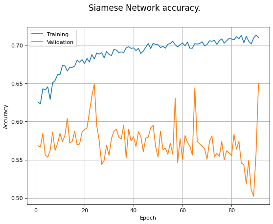

```python
plt.figure(figsize=(8, 6), dpi=80)
plt.plot(range(1,len(snn_model_history.history['accuracy'])+1),
         snn_model_history.history['accuracy'])
plt.plot(range(1,len(snn_model_history.history['val_accuracy'])+1),
         snn_model_history.history['val_accuracy'])
plt.suptitle('Siamese Network accuracy.', fontsize = 15)
plt.grid()
plt.ylabel('Accuracy')
plt.xlabel('Epoch')
plt.legend(['Training', 'Validation'], loc='best')
plt.show()
```

```python
%%shell
jupyter nbconvert --to html /content/AG_DLS_HW_4.ipynb
jupyter nbconvert --to html /content/AG_DLS_HW_4_pb_4_LSTM.ipynb
```

```
[NbConvertApp] Converting notebook /content/AG_DLS_HW_4.ipynb to html
[NbConvertApp] Writing 512201 bytes to /content/AG_DLS_HW_4.html
[NbConvertApp] Converting notebook /content/AG_DLS_HW_4_pb_4_LSTM.ipynb to html
[NbConvertApp] Writing 686310 bytes to /content/AG_DLS_HW_4_pb_4_LSTM.html
```